# Slides in R Markdown

30 May 2019

## (R) Markdown May in almost over!

- Just making sure that you’ve seen these links:

  https://rmarkdown.rstudio.com/index.html

  https://rmarkdown.rstudio.com/lesson-1.html
- This is a great guide to using R Markdown within the R Studio environment.
- This is also awesome:

  https://bookdown.org/yihui/rmarkdown/presentations.html
- Today we’re going to use R Markdown to make some presentation slides (just like these ones).

## Slides in R markdown

From: https://rmarkdown.rstudio.com/lesson-11.html

## New presentation

- File menu:
  - New File -> Rmarkdown…
- Select “Presentation” and click “OK”

[figure not shown]

## Your new document

- Following the steps on the previous slide will produce a new R Markdown *presentation*, complete with some example text and code.
- It should look suspiciously familiar…
- What is the difference between this and a R Markdown *document*?

## YAML header

**R Markdown document:**

```
---
title: "Untitled"
author: "Mik Black"
date: "28/05/2019"
output: html_document
---
```

**R Markdown presentation:**

```
---
title: "Untitled"
author: "Mik Black"
date: "28/05/2019"
output: ioslides_presentation
---
```

## Let’s see what is in the example slides

## Slide 1 (title slide): code

```
---
title: "Untitled"
author: "Mik Black"
date: "28/05/2019"
output: ioslides_presentation
---
```

## Slide 2: code

```
## R Markdown

This is an R Markdown presentation. Markdown is a simple formatting
syntax for authoring HTML, PDF, and MS Word documents. For more
details on using R Markdown see <http://rmarkdown.rstudio.com>.

When you click the **Knit** button a document will be generated
that includes both content as well as the output of any embedded
R code chunks within the document.
```

## Slide 3: code

```
## Slide with Bullets

- Bullet 1
- Bullet 2
- Bullet 3
```

## Slide with Bullets

- Bullet 1
- Bullet 2
- Bullet 3

## Slide 4: code

[output not shown]

## Slide 5: code

````
## Slide with Plot

```{r pressure}
plot(pressure)
```
````

## Slide with Plot

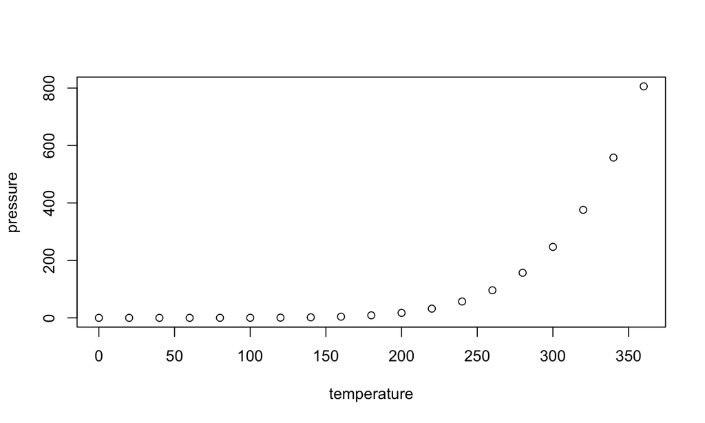

## Echoing code

- Note that code is not displayed by default
- This can be specified per code chunk:

````
  ```{r cars, echo = TRUE}
  summary(cars)
  ```
````

- Or you can define it globally at the top of the file (after the YAML header):

````
  ```{r setup, include=FALSE}
  knitr::opts_chunk$set(echo = TRUE)
  ```
````

## Let’s make a presentation…

- File menu:
  - New File -> Rmarkdown…
- Select “Presentation” and click “OK”

[figure not shown]

## …and customise it

- Give it a proper title
- Click “Knit” to generate the output
- Click the “Open in Browser” button (at the top of the output page) to open the slides in a web browser.
- Try adding some content - perhaps a slide containing a boxplot:

  `boxplot( cars$speed )`

## Inserting an image

- The following code will add an image to the slide (note, this isn’t R code, it’s Markdown, so doesn’t sit in a code chunk):

```
  ![some text](figures/img.png)
```

some text

## How I do it

- Simple HTML code can also be used:

```
  <center>
  <img src="figures/otago_logo.jpg" width="400">
  </center>
```

## And here is the newer cooler way…

- `knitr` now includes a built-in function for this:

````
  ```{r, out.width = "400px", fig.align="center"}
  knitr::include_graphics("figures/otago_logo.jpg")
  ```
````

## Using an image URL

- You can also load an image directly from the web (make sure you have internet connectivity when you knit your document):

````
  ```{r, out.width = "400px", fig.align="center"}
  fig <- 'https://carpentries.org/images/TheCarpentries-opengraph.png'
  knitr::include_graphics(fig)
  ```
````

[figure not shown]

## Random tricks!

## Like - what’s with that grey slide?

- If you use a single hash for the slide title, you get a grey-background “transition slide”

```
  # Random tricks!
```

- Note that most of my “random tricks” are directly from:

  https://bookdown.org/yihui/rmarkdown/presentations.html

## Math formulae

- LaTeX commands can be used to insert equations.
- Code

```
    $\pi(\theta|X) = \frac{f(X|\theta)\pi(\theta)}
                     {\int{f(X|\theta)\pi(\theta)d\theta}}$
```

- Output:

\(\pi(\theta|X) = \frac{f(X|\theta)\pi(\theta)}{\int{f(X|\theta)\pi(\theta)d\theta}}\)

## Size changes

- You can display the presentation using a wider form factor using the widescreen option. You can specify that smaller text be used with the smaller option. For example:

```
  ---
  output:
    ioslides_presentation:
      widescreen: true
      smaller: true
  ---
```

- You can also enable the “smaller” option on a slide-by-slide basis by adding the .smaller attribute to the slide header:

```
  ## Title {.smaller}
```

## Smaller text slide

- The text on this slide is smaller
- You could use this if you need to squeeze some more words in…

## Incremental bullets

- You can render bullets incrementally by adding the incremental option:

```
  ---
  output:
    ioslides_presentation:
      incremental: true
  ---
```

- If you want to render bullets incrementally for some slides but not others you can (ab)use this syntax for blockquotes:

```
  > - Eat eggs
  > - Drink coffee
```

## Two column layout

````
<div class="columns-2">

```{r, out.width = "300px"}
knitr::include_graphics("figures/otago_logo.jpg")
```

- Bullet 1
- Bullet 2
- Bullet 3

</div>
````

- Bullet 1
- Bullet 2
- Bullet 3

## Text colour

You can color content using base color classes red, blue, green, yellow, and gray (or variations of them, e.g., red2, red3, blue2, blue3, etc.). For example:

```
<div class="red2">
This text is red
</div>
```

This text is red

## Pretty tables

```r
library(dplyr)
summary(cars) %>% knitr::kable()
```

|  | speed | dist |
| --- | --- | --- |
|  | Min. : 4.0 | Min. : 2.00 |
|  | 1st Qu.:12.0 | 1st Qu.: 26.00 |
|  | Median :15.0 | Median : 36.00 |
|  | Mean :15.4 | Mean : 42.98 |
|  | 3rd Qu.:19.0 | 3rd Qu.: 56.00 |
|  | Max. :25.0 | Max. :120.00 |

## In summary

- Making cool looking presentations using R Markdown is super easy.
- There are MANY ways to tweak your slides
  - see links at the start of this document
  - lots of other online resources
- Advantages:
  - analyses are built-in and reproducible
  - outputs are automatically integrated into the document
  - fits seamlessly into an R-centric workflow
  - text-based document makes version control with Git easy